# Comparative analysis of classification models, bagging, cross-validation

### Cognition comes by comparison! Friedrich Wilhelm Nietzsche

The best knowledge can be obtained by comparing many models from different perspectives. In this study, I used data about people studying whether they would have a stroke or not.Withh the help of predict_prob with a properly working model, it is possible to provide each test person with the probability that they will have a stroke. By controlling age, you can show him the likelihood of stroke in the next years of life. The database is easily available on the internet.

In my research I used this database but changed the formula of the analysis slightly. I imagined it was a test for the currently popular COVID-19. With tests on COVID-19 it is like this:

1. It is important and even crucial that they have tests give high detectability because if we release a patient who will have COVID-19 and we will say that he is healthy. It can infect many people and put them at risk of losing their lives. Poor detection also means having to repeat tests, which is expensive and inefficient.
2. It is also important not to scare healthy people that they have COVID-19.

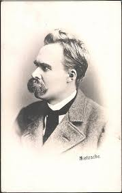

Friedrich Wilhelm Nietzsche

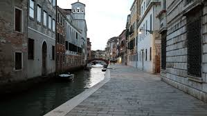

```python
import pandas as pd
import numpy as np
import seaborn as sns
import matplotlib.pyplot as plt
import warnings
from sklearn.ensemble import BaggingClassifier
from simple_colors import *
from prettytable import PrettyTable

warnings.filterwarnings("ignore")

%matplotlib inline

df= pd.read_csv('/home/wojciech/Pulpit/1/Stroke_Prediction.csv')
print(df.shape)
print()
print(df.columns)
df.head(3)
```

```
(43400, 12)

Index(['ID', 'Gender', 'Age_In_Days', 'Hypertension', 'Heart_Disease',
       'Ever_Married', 'Type_Of_Work', 'Residence', 'Avg_Glucose', 'BMI',
       'Smoking_Status', 'Stroke'],
      dtype='object')
```

|  | ID | Gender | Age_In_Days | Hypertension | Heart_Disease | Ever_Married | Type_Of_Work | Residence | Avg_Glucose | BMI | Smoking_Status | Stroke |
| --- | --- | --- | --- | --- | --- | --- | --- | --- | --- | --- | --- | --- |
| 0 | 31153 | Male | 1104.0 | 0 | 0 | No | children | Rural | 95.12 | 18.0 | NaN | 0 |
| 1 | 30650 | Male | 21204.0 | 1 | 0 | Yes | Private | Urban | 87.96 | 39.2 | never smoked | 0 |
| 2 | 17412 | Female | 2928.0 | 0 | 0 | No | Private | Urban | 110.89 | 17.6 | NaN | 0 |

Sample reduction:

```python
df = df.sample(frac = 0.5, random_state=10)
df.shape
```

```
(21700, 12)
```

#### Start pomiaru czasu

```python
import time
start_time = time.time() ## pomiar czasu: start pomiaru czasu
print(time.ctime())
```

```
Wed Jun  3 22:38:49 2020
```

### Tool for automatic coding of discrete variables

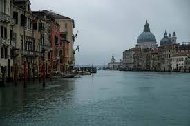

```python
a,b = df.shape     #<- ile mamy kolumn
b

print('DISCRETE FUNCTIONS CODED')
print('------------------------')
for i in range(1,b):
    i = df.columns[i]
    f = df[i].dtypes
    if f == np.object:
        print(i,"---",f)

        if f == np.object:

            df[i] = pd.Categorical(df[i]).codes

            continue
```

```
DISCRETE FUNCTIONS CODED
------------------------
Gender --- object
Ever_Married --- object
Type_Of_Work --- object
Residence --- object
Smoking_Status --- object
```

```python
df.fillna(7777, inplace=True)
```

```python
X = df.drop('Stroke', axis=1)
y = df['Stroke']

from sklearn.model_selection import train_test_split
X_train, X_test, y_train, y_test = train_test_split(X, y, test_size=0.20, random_state=123,stratify=y)
```

# Oversampling !!

[figure not shown]

```python
def oversampling(ytrain, Xtrain):
    import matplotlib.pyplot as plt

    global Xtrain_OV
    global ytrain_OV

    calss1 = np.round((sum(ytrain == 1)/(sum(ytrain == 0)+sum(ytrain == 1))),decimals=2)*100
    calss0 = np.round((sum(ytrain == 0)/(sum(ytrain == 0)+sum(ytrain == 1))),decimals=2)*100

    print("y = 0: ", sum(ytrain == 0),'-------',calss0,'%')
    print("y = 1: ", sum(ytrain == 1),'-------',calss1,'%')
    print('--------------------------------------------------------')

    ytrain.value_counts(dropna = False, normalize=True).plot(kind='pie',title='Before oversampling')
    plt.show
    print()

    Proporcja = sum(ytrain == 0) / sum(ytrain == 1)
    Proporcja = np.round(Proporcja, decimals=0)
    Proporcja = Proporcja.astype(int)

    ytrain_OV = pd.concat([ytrain[ytrain==1]] * Proporcja, axis = 0)
    Xtrain_OV = pd.concat([Xtrain.loc[ytrain==1, :]] * Proporcja, axis = 0)

    ytrain_OV = pd.concat([ytrain, ytrain_OV], axis = 0).reset_index(drop = True)
    Xtrain_OV = pd.concat([Xtrain, Xtrain_OV], axis = 0).reset_index(drop = True)

    Xtrain_OV = pd.DataFrame(Xtrain_OV)
    ytrain_OV = pd.DataFrame(ytrain_OV)



    print("Before oversampling Xtrain:     ", Xtrain.shape)
    print("Before oversampling ytrain:     ", ytrain.shape)
    print('--------------------------------------------------------')
    print("After oversampling Xtrain_OV:  ", Xtrain_OV.shape)
    print("After oversampling ytrain_OV:  ", ytrain_OV.shape)
    print('--------------------------------------------------------')


    ax = plt.subplot(1, 2, 1)
    ytrain.value_counts(dropna = False, normalize=True).plot(kind='pie',title='Before oversampling')
    plt.show


    kot = pd.concat([ytrain[ytrain==1]] * Proporcja, axis = 0)
    kot = pd.concat([ytrain, kot], axis = 0).reset_index(drop = True)
    ax = plt.subplot(1, 2, 2)
    kot.value_counts(dropna = False, normalize=True).plot(kind='pie',title='After oversampling')
    plt.show
```

```
y = 0:  17040 ------- 98.0 %
y = 1:  320 ------- 2.0 %
--------------------------------------------------------

Before oversampling Xtrain:      (17360, 11)
Before oversampling ytrain:      (17360,)
--------------------------------------------------------
After oversampling Xtrain_OV:   (34320, 11)
After oversampling ytrain_OV:   (34320, 1)
--------------------------------------------------------
```

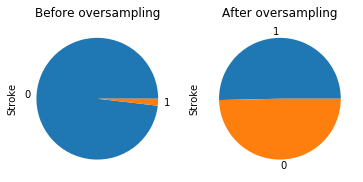

```python
oversampling(y_train, X_train)
```

I get rid of one dimension from the ytrain_OV set so that the set is similar to y_test.

```python
print(Xtrain_OV.shape)
print(ytrain_OV.shape)
ytrain_OV = ytrain_OV['Stroke']
print(ytrain_OV.shape)
```

```
(34320, 11)
(34320, 1)
(34320,)
```

W poprzednim wpisie uznaliśmy, że oversampling poprawiło jakość klasyfikacji. Kolejne działania będą opierały sie na danych zbilansowanych przez oversampling. Dlatego teraz podmieniamy zwykłą próbę na próbę po oversamoling.

```python
X_train = Xtrain_OV
y_train = ytrain_OV
print(X_train.shape)
print(y_train.shape)
```

```
(34320, 11)
(34320,)
```

## Oversampling for cross-validation

Cross-validation should be done for a full set. therefore oversampling should be performed for a balanced set first. In my exercise I took a shortcut and did oversampling on a training set. However, I left this option. There are a lot of working but disabled analytical functions in this file.

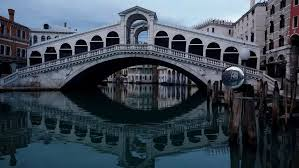

```python
X = df.drop('Stroke', axis=1)
y = df['Stroke']
```

```python
X.shape
```

```
(21700, 11)
```

```
y = 0:  21300 ------- 98.0 %
y = 1:  400 ------- 2.0 %
--------------------------------------------------------

Before oversampling Xtrain:      (21700, 11)
Before oversampling ytrain:      (21700,)
--------------------------------------------------------
After oversampling Xtrain_OV:   (42900, 11)
After oversampling ytrain_OV:   (42900, 1)
--------------------------------------------------------
```

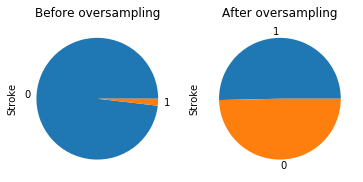

```python
oversampling(y, X)
```

```python
Data = Xtrain_OV
target = ytrain_OV
print("output:",Data.shape)
print("output:",target.shape)
print('----------')
print("input:", df.shape)
```

```
output: (42900, 11)
output: (42900, 1)
----------
input: (21700, 12)
```

1. Normal classifiers after oversampling,
2. Classifiers after bagging
3. Standard calibrators
4. Classifiers after bagging calibrated

### Below are 2 basic groups: 1. Classifiers after oversampling, 2. Classifiers after bagging

```python
from sklearn.naive_bayes import GaussianNB
from sklearn.linear_model import LogisticRegression
from sklearn.ensemble import GradientBoostingClassifier
from sklearn.ensemble import RandomForestClassifier
from lightgbm import LGBMClassifier
from sklearn.ensemble import RandomForestClassifier
from catboost import CatBoostClassifier
from sklearn.svm import SVC
from xgboost import XGBClassifier
from sklearn.tree import DecisionTreeClassifier
from sklearn.neighbors import KNeighborsClassifier
from sklearn.svm import SVC
import time

NBC = GaussianNB()
LRE = LogisticRegression(solver='lbfgs')
GBC = GradientBoostingClassifier()
RFC = RandomForestClassifier()
LGBM = LGBMClassifier()
CBC = CatBoostClassifier(verbose=0, n_estimators=100)
XGB = XGBClassifier()
LREN = LogisticRegression(solver='newton-cg')
KNN = KNeighborsClassifier(n_neighbors=1, p=2)
SVM = SVC(probability=True)


classifiers_A = [SVM,CBC,XGB,LGBM,KNN,NBC,LRE,RFC,GBC]
nameA = ['SVM','CBC','XGB','LGBM','KNN','NBC','LRE','RFC','GBC']

for n,t in zip(nameA,classifiers_A):          ## Szkolenie modeli w pętli
    start_time = time.time()
    t.fit(X_train, y_train)
    p = np.round((time.time() - start_time),decimals=1)
    print(blue(n),p,"---",time.ctime())



### Wzmacnianie przez bagowanie!

NBC_b = BaggingClassifier(base_estimator=NBC, n_estimators=10, max_samples=0.8, max_features=0.8)
LRE_b = BaggingClassifier(base_estimator=LRE, n_estimators=10, max_samples=0.8, max_features=0.8)
GBC_b = BaggingClassifier(base_estimator=GBC, n_estimators=10, max_samples=0.8, max_features=0.8)
RFC_b = BaggingClassifier(base_estimator=RFC, n_estimators=10, max_samples=0.8, max_features=0.8)
LGBM_b = BaggingClassifier(base_estimator=LGBM, n_estimators=10, max_samples=0.8, max_features=0.8)
CBC_b = BaggingClassifier(base_estimator=CBC, n_estimators=10, max_samples=0.8, max_features=0.8)
XGB_b = BaggingClassifier(base_estimator=XGB, n_estimators=10, max_samples=0.8, max_features=0.8)
SVM_b = BaggingClassifier(base_estimator=SVM, n_estimators=10, max_samples=0.8, max_features=0.8)
KNN_b = BaggingClassifier(base_estimator=KNN, n_estimators=10, max_samples=0.8, max_features=0.8)



classifiers_B = [SVM_b,CBC_b,XGB_b,LGBM_b,KNN_b,NBC_b,LRE_b,RFC_b,GBC_b]
nameB = ['SVM_b','CBC_b','XGB_b','LGBM_b','KNN_b','NBC_b','LRE_b','RFC_b','GBC_b']

print('-------------------------------------')

for f,p in zip(nameB,classifiers_B):            ## Szkolenie zbagowanych modeli w pętli
    start_time = time.time()
    p.fit(X_train, y_train)
    k = np.round((time.time() - start_time),decimals=1)
    print(blue(f),k,"---",time.ctime())
```

```
SVM 268.5 --- Wed Jun  3 22:43:19 2020
CBC 1.3 --- Wed Jun  3 22:43:20 2020
XGB 2.2 --- Wed Jun  3 22:43:23 2020
LGBM 1.2 --- Wed Jun  3 22:43:24 2020
KNN 0.1 --- Wed Jun  3 22:43:24 2020
NBC 0.0 --- Wed Jun  3 22:43:24 2020
LRE 0.5 --- Wed Jun  3 22:43:24 2020
RFC 3.7 --- Wed Jun  3 22:43:28 2020
GBC 5.3 --- Wed Jun  3 22:43:33 2020
-------------------------------------
SVM_b 857.7 --- Wed Jun  3 22:57:51 2020
CBC_b 6.6 --- Wed Jun  3 22:57:58 2020
XGB_b 11.5 --- Wed Jun  3 22:58:09 2020
LGBM_b 3.7 --- Wed Jun  3 22:58:13 2020
KNN_b 0.5 --- Wed Jun  3 22:58:13 2020
NBC_b 0.1 --- Wed Jun  3 22:58:13 2020
LRE_b 2.1 --- Wed Jun  3 22:58:15 2020
RFC_b 17.6 --- Wed Jun  3 22:58:33 2020
GBC_b 25.6 --- Wed Jun  3 22:58:59 2020
```

# Cross validation

#### Division into folds for all models:

```python
from sklearn.model_selection import RepeatedStratifiedKFold

cv_method = RepeatedStratifiedKFold(n_splits=5,            # 5-krotna weryfikacja krzyżowa
                                    n_repeats=3,           # z 3-ema powtórzeniami
                                    random_state=999)
```

### A set of hyperparameters for each model:

```python
params_KNN = {'n_neighbors': [1, 2, 3, 4, 5, 6, 7], 'p': [1, 2, 5]}
params_NBC = {'var_smoothing': np.logspace(0,-9, num=100)}
params_LRE = {'C': np.power(10.0, np.arange(-3, 3))}
params_RFC = {
 'max_depth': [5, 8],
 'max_features': ['auto'],
 'min_samples_leaf': [1, 2],
 'min_samples_split': [2, 5],
 'n_estimators':  [100,  200, ]}

#n_estimators = [100, 300, 500, 800, 1200]
#max_depth = [5, 8, 15, 25, 30]
#min_samples_split = [2, 5, 10, 15, 100]
#min_samples_leaf = [1, 2, 5, 10]

params_RFC2 = {
 'max_depth': [2, 3],
 'min_samples_leaf': [3, 4],
 'n_estimators':  [500,1000]}

params_GBC = {
    'min_samples_split':range(1000,2100,200),
    'min_samples_leaf':range(30,71,10)}

#{'max_depth':range(5,16,2), 'min_samples_split':range(200,1001,200)}
#{'n_estimators':range(20,81,10)}
# https://www.analyticsvidhya.com/blog/2016/02/complete-guide-parameter-tuning-gradient-boosting-gbm-python/

params_GBC2 = {
    'max_depth':range(5,16,2),
    'min_samples_split':range(200,1001),
    'n_estimators':range(20,81)}

params_CBC = {'learning_rate': [0.03, 0.1],
        'depth': [4, 6, 10],
        'l2_leaf_reg': [1, 3, 5, 7, 9]}


params_LGBM = {'max_depth': [3, 6, 9],'learning_rate': [0.001, 0.01, 0.05]}

params_XGB = {"learning_rate": [0.05, 0.15, 0.25 ], "max_depth": [ 3, 6, 9], "gamma":[ 0.0, 0.1, 0.4 ] }

params_SVM = {'C': [0.1,1, 10, 100], 'kernel': ['rbf']}
## {'C': [0.1,1, 10, 100], 'gamma': [1,0.1,0.01,0.001],'kernel': ['rbf', 'poly', 'sigmoid']}

params_SVM2 = {'C': [0.1,1, 10, 100],'kernel': ['poly']}
## {'C': [0.1,1, 10, 100], 'gamma': [1,0.1,0.01,0.001],'kernel': ['rbf', 'poly', 'sigmoid']}
```

### Inserting each model into the grid seat:

```python
from sklearn.model_selection import GridSearchCV


##==============================================================================

gs_KNN = GridSearchCV(estimator=KNeighborsClassifier(),
                      param_grid=params_KNN,
                      cv=cv_method,
                      verbose=1,  # verbose: the higher, the more messages
                      scoring='roc_auc',
                      return_train_score=True)

##==============================================================================

gs_NBC = GridSearchCV(estimator=NBC,
                     param_grid=params_NBC,
                     cv=cv_method,
                     verbose=1,
                     scoring='roc_auc')

##==============================================================================

gs_LRE = GridSearchCV(estimator=LRE,
                      param_grid = params_LRE,
                      cv=cv_method,
                      verbose=1,
                      scoring = 'roc_auc')

##==============================================================================

gs_RFC = GridSearchCV(estimator=RFC,
                      param_grid = params_RFC,
                      cv=cv_method,
                      verbose=1,
                      scoring = 'roc_auc')

##==============================================================================

gs_RFC2 = GridSearchCV(estimator=RFC,
                      param_grid = params_RFC2,
                      cv=cv_method,
                      verbose=1,
                      scoring = 'roc_auc')

##==============================================================================

gs_GBC = GridSearchCV(estimator=GBC,
                      param_grid = params_GBC,
                      cv=cv_method,
                      verbose=1,
                      scoring = 'roc_auc')

##==============================================================================

gs_GBC2 = GridSearchCV(estimator=GBC,
                      param_grid = params_GBC2,
                      cv=cv_method,
                      verbose=1,
                      scoring = 'roc_auc')

##==============================================================================

gs_CBC = GridSearchCV(estimator=GBC,
                      param_grid = params_CBC,
                      cv=cv_method,
                      verbose=1,
                      scoring = 'roc_auc')

##==============================================================================

gs_XGB = GridSearchCV(estimator=XGB,
                      param_grid = params_XGB,
                      cv=cv_method,
                      verbose=1,
                      scoring = 'roc_auc')

##==============================================================================

gs_LGBM = GridSearchCV(estimator=GBC,
                      param_grid = params_LGBM,
                      cv=cv_method,
                      verbose=1,
                      scoring = 'roc_auc')
##==============================================================================

gs_SVM = GridSearchCV(estimator=SVM,
                      param_grid = params_SVM,
                      cv=cv_method,
                      verbose=1,
                      scoring = 'roc_auc')

##==============================================================================

gs_SVM2 = GridSearchCV(estimator=SVM,
                      param_grid = params_SVM2,
                      cv=cv_method,
                      verbose=1,
                      scoring = 'roc_auc')
```

### Exercise model using the full range of balanced data (after oversample):

```python
classifiers_F = [gs_SVM,gs_SVM2,gs_XGB,gs_LGBM,gs_KNN,gs_NBC,gs_LRE,gs_RFC,gs_RFC2]
nameF = ['gs_SVM','gs_SVM2','gs_XGB','gs_LGBM','gs_KNN','gs_NBC','gs_LRE','gs_RFC','gs_RFC2']
```

```python
for n,t in zip(nameF,classifiers_F):          ## Szkolenie modeli w pętli
    start_time = time.time()
    t.fit(X_train, y_train)
    p = np.round((time.time() - start_time),decimals=1)
    print(blue(n),p,"---",time.ctime())
```

```
Fitting 15 folds for each of 4 candidates, totalling 60 fits
```

```
[Parallel(n_jobs=1)]: Using backend SequentialBackend with 1 concurrent workers.
[Parallel(n_jobs=1)]: Done  60 out of  60 | elapsed: 183.0min finished
```

```
gs_SVM 11241.6 --- Thu Jun  4 02:06:20 2020
Fitting 15 folds for each of 4 candidates, totalling 60 fits
```

```
[Parallel(n_jobs=1)]: Using backend SequentialBackend with 1 concurrent workers.
[Parallel(n_jobs=1)]: Done  60 out of  60 | elapsed: 216.1min finished
```

```
gs_SVM2 13208.1 --- Thu Jun  4 05:46:28 2020
Fitting 15 folds for each of 27 candidates, totalling 405 fits
```

```
[Parallel(n_jobs=1)]: Using backend SequentialBackend with 1 concurrent workers.
[Parallel(n_jobs=1)]: Done 405 out of 405 | elapsed:  7.4min finished
```

```
gs_XGB 447.6 --- Thu Jun  4 05:53:56 2020
Fitting 15 folds for each of 9 candidates, totalling 135 fits
```

```
[Parallel(n_jobs=1)]: Using backend SequentialBackend with 1 concurrent workers.
[Parallel(n_jobs=1)]: Done 135 out of 135 | elapsed: 17.5min finished
```

```
gs_LGBM 1064.2 --- Thu Jun  4 06:11:40 2020
Fitting 15 folds for each of 21 candidates, totalling 315 fits
```

```
[Parallel(n_jobs=1)]: Using backend SequentialBackend with 1 concurrent workers.
[Parallel(n_jobs=1)]: Done 315 out of 315 | elapsed:  7.3min finished
[Parallel(n_jobs=1)]: Using backend SequentialBackend with 1 concurrent workers.
```

```
gs_KNN 437.5 --- Thu Jun  4 06:18:58 2020
Fitting 15 folds for each of 100 candidates, totalling 1500 fits
```

```
[Parallel(n_jobs=1)]: Done 1500 out of 1500 | elapsed:   29.1s finished
[Parallel(n_jobs=1)]: Using backend SequentialBackend with 1 concurrent workers.
```

```
gs_NBC 29.1 --- Thu Jun  4 06:19:27 2020
Fitting 15 folds for each of 6 candidates, totalling 90 fits
```

```
[Parallel(n_jobs=1)]: Done  90 out of  90 | elapsed:   17.5s finished
```

```
gs_LRE 18.1 --- Thu Jun  4 06:19:45 2020
Fitting 15 folds for each of 16 candidates, totalling 240 fits
```

```
[Parallel(n_jobs=1)]: Using backend SequentialBackend with 1 concurrent workers.
[Parallel(n_jobs=1)]: Done 240 out of 240 | elapsed: 11.4min finished
```

```
gs_RFC 686.6 --- Thu Jun  4 06:31:12 2020
Fitting 15 folds for each of 8 candidates, totalling 120 fits
```

```
[Parallel(n_jobs=1)]: Using backend SequentialBackend with 1 concurrent workers.
[Parallel(n_jobs=1)]: Done 120 out of 120 | elapsed: 16.0min finished
```

```
gs_RFC2 973.2 --- Thu Jun  4 06:47:25 2020
```

### Checking the best set of hyperparameters:

```python
print('Best params gs_SVM:', gs_SVM.best_params_)
print('Best params gs_SVM2:', gs_SVM2.best_params_)
print('Best params gs_XGB:', gs_XGB.best_params_)
print('Best params gs_LGBM:', gs_LGBM.best_params_)
print('Best params gs_KNN:', gs_KNN.best_params_)
print('Best params gs_NBC:', gs_NBC.best_params_)
print('Best params gs_LRE:', gs_LRE.best_params_)
print('Best params gs_RFC:', gs_RFC.best_params_)
print('Best params gs_RFC2:', gs_RFC2.best_params_)
```

```
Best params gs_SVM: {'C': 1, 'kernel': 'rbf'}
Best params gs_SVM2: {'C': 10, 'kernel': 'poly'}
Best params gs_XGB: {'gamma': 0.4, 'learning_rate': 0.25, 'max_depth': 9}
Best params gs_LGBM: {'learning_rate': 0.05, 'max_depth': 9}
Best params gs_KNN: {'n_neighbors': 1, 'p': 5}
Best params gs_NBC: {'var_smoothing': 0.01873817422860384}
Best params gs_LRE: {'C': 0.01}
Best params gs_RFC: {'max_depth': 8, 'max_features': 'auto', 'min_samples_leaf': 2, 'min_samples_split': 5, 'n_estimators': 200}
Best params gs_RFC2: {'max_depth': 3, 'min_samples_leaf': 3, 'n_estimators': 1000}
```

## Time is money

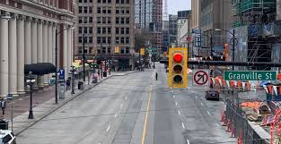

## The most important type of Type_error set for me

#### False_Positive_Rate

```
- percentage share of healthy people recognized by the model as sick in the population of healthy people
```

#### True_Positive_Rate RECALL

```
- this indicator shows how detectable the disease is by the model.
```

```python
def Type_error(six_classifiers,name, X_train, y_train,X_test,y_test,calibration=True):


    from sklearn.datasets import make_classification
    from sklearn.calibration import CalibratedClassifierCV, calibration_curve
    from sklearn.metrics import confusion_matrix

    from sklearn import metrics
    import simple_colors
    import time

    start_time = time.time()

    #for cls in six_classifiers:
    #    cls.fit(X_train, y_train)

    FPR = ['False_Positive_Rate:']
    TPR = ['True_Positive_Rate: ']
    FNR = ['False_Negative_Rate: ']
    SPEC = ['Specifity']

    CAL_FPR = ['CAL_False_Positive_Rate:']
    CAL_TPR = ['CAL_True_Positive_Rate: ']
    CAL_FNR = ['CAL_False_Negative_Rate: ']
    CAL_SPEC = ['CAL_Specifity']

    def compute_metric(model):


        #model = model.fit(X_train,y_train)   #<-- model już przećwiczył się na pełnych danych
        cm = confusion_matrix(y_test, model.predict(X_test))
        tn, fp, fn, tp = cm.ravel()
        # print('tn: ',tn)
        # print('fp: ',fp)
        # print('fn: ',fn)
        # print('tp: ',tp)
        # print('------------------')
        # print(cm)


        FPR = np.round(fp/(fp + tn),decimals=3)
        TPR = np.round(tp/(tp + fn),decimals=3)
        FNR = np.round(fn/(tp + fn),decimals=3)
        SPEC = np.round(tn/(tn + fp),decimals=3)

        return FPR,TPR,FNR,SPEC

    for cls in six_classifiers:

        results = compute_metric(cls)
        FPR.append(red(results[0],'bold'))
        TPR.append(red(results[1],'bold'))
        FNR.append(results[2])
        SPEC.append(results[3])

    t = PrettyTable(['Name', name[0],name[1],name[2],name[3],name[4],name[5],name[6],name[7],name[8]])
    t.add_row(FPR)
    t.add_row(TPR)
    t.add_row(FNR)
    t.add_row(SPEC)

    print(blue('Models before calibration','bold'))
    g = (time.time() - start_time)
    g = np.round(g)
    print('time: %s seconds' % g)
    print(t)
  ## --------------------------------------------------

    if calibration != True:
        print()
    else:
        print(blue('Models after calibration','bold'))

        start_time = time.time()

        def calibration(model):

            calibrated = CalibratedClassifierCV(model, method='sigmoid', cv=5)
            calibrated.fit(X_train, y_train)

            ck = confusion_matrix(y_test, calibrated.predict(X_test))
            tn_c, fp_c, fn_c, tp_c = ck.ravel()
            # print('tn: ',tn)
            # print('fp: ',fp)
            # print('fn: ',fn)
            # print('tp: ',tp)
            # print('------------------')
            # print(cm)


            CAL_FPR = np.round(fp_c/(fp_c + tn_c),decimals=3)
            CAL_TPR = np.round(tp_c/(tp_c + fn_c),decimals=3)
            CAL_FNR = np.round(fn_c/(tp_c + fn_c),decimals=3)
            CAL_SPEC = np.round(tn_c/(tn_c + fp_c),decimals=3)

            return CAL_FPR, CAL_TPR, CAL_FNR, CAL_SPEC

        for cls in six_classifiers:

            results = calibration(cls)
            CAL_FPR.append(red(results[0],'bold'))
            CAL_TPR.append(red(results[1],'bold'))
            CAL_FNR.append(results[2])
            CAL_SPEC.append(results[3])

        k = PrettyTable(['Name', name[0],name[1],name[2],name[3],name[4],name[5],name[6],name[7],name[8]])
        k.add_row(CAL_FPR)
        k.add_row(CAL_TPR)
        k.add_row(CAL_FNR)
        k.add_row(CAL_SPEC)


        n = (time.time() - start_time)
        n = np.round(n)
        print('time: %s seconds' % n)
        print(k)


    print(red('False_Positive_Rate','bold'),red('procentowy udział ludzi zdrowych uznanych przez model za chorych w populacji ludzi zdrowych','italic'))
    print(red('True_Positive_Rate RECALL','bold'), red('procentowy udział chorych dobrze zdiagnozowanych w populacji ludzi chorych ogółem','italic'))
    print(black('False_Negative_Rate','bold'), black('procentowy udział niewykrytych chorych w populacji ludzi chorych ogółem','italic'))
    print(black('Specifity','bold'), black('procentowy udział ludzi zdrowych uznanych za zdrowych w populacji ludzi zdrowych','italic'))
```

```python
Type_error(classifiers_A,nameA,X_train, y_train,X_test,y_test,calibration=False)
```

```
Models before calibration
time: 4.0 seconds
+-----------------------+-------+-------+-------+-------+-------+-------+-------+-------+-------+
|          Name         |  SVM  |  CBC  |  XGB  |  LGBM |  KNN  |  NBC  |  LRE  |  RFC  |  GBC  |
+-----------------------+-------+-------+-------+-------+-------+-------+-------+-------+-------+
|  False_Positive_Rate: | 0.315 | 0.074 | 0.018 | 0.065 |  0.02 | 0.216 | 0.285 |  0.0  | 0.201 |
|  True_Positive_Rate:  | 0.838 |  0.3  | 0.038 | 0.312 | 0.075 | 0.775 |  0.8  | 0.012 |  0.7  |
| False_Negative_Rate:  | 0.162 |  0.7  | 0.962 | 0.688 | 0.925 | 0.225 |  0.2  | 0.988 |  0.3  |
|       Specifity       | 0.685 | 0.926 | 0.982 | 0.935 |  0.98 | 0.784 | 0.715 |  1.0  | 0.799 |
+-----------------------+-------+-------+-------+-------+-------+-------+-------+-------+-------+

False_Positive_Rate procentowy udział ludzi zdrowych uznanych przez model za chorych w populacji ludzi zdrowych
True_Positive_Rate RECALL procentowy udział chorych dobrze zdiagnozowanych w populacji ludzi chorych ogółem
False_Negative_Rate procentowy udział niewykrytych chorych w populacji ludzi chorych ogółem
Specifity procentowy udział ludzi zdrowych uznanych za zdrowych w populacji ludzi zdrowych
```

```python
Type_error(classifiers_F,nameF,X_train, y_train,X_test,y_test,calibration=False)
```

```
Models before calibration
time: 7.0 seconds
+-----------------------+--------+---------+--------+---------+--------+--------+--------+--------+---------+
|          Name         | gs_SVM | gs_SVM2 | gs_XGB | gs_LGBM | gs_KNN | gs_NBC | gs_LRE | gs_RFC | gs_RFC2 |
+-----------------------+--------+---------+--------+---------+--------+--------+--------+--------+---------+
|  False_Positive_Rate: | 0.315  |  0.216  | 0.007  |  0.052  | 0.019  | 0.315  | 0.287  | 0.192  |  0.343  |
|  True_Positive_Rate:  | 0.838  |   0.75  | 0.025  |  0.288  | 0.075  | 0.838  |  0.8   |  0.65  |  0.825  |
| False_Negative_Rate:  | 0.162  |   0.25  | 0.975  |  0.712  | 0.925  | 0.162  |  0.2   |  0.35  |  0.175  |
|       Specifity       | 0.685  |  0.784  | 0.993  |  0.948  | 0.981  | 0.685  | 0.713  | 0.808  |  0.657  |
+-----------------------+--------+---------+--------+---------+--------+--------+--------+--------+---------+

False_Positive_Rate procentowy udział ludzi zdrowych uznanych przez model za chorych w populacji ludzi zdrowych
True_Positive_Rate RECALL procentowy udział chorych dobrze zdiagnozowanych w populacji ludzi chorych ogółem
False_Negative_Rate procentowy udział niewykrytych chorych w populacji ludzi chorych ogółem
Specifity procentowy udział ludzi zdrowych uznanych za zdrowych w populacji ludzi zdrowych
```

```python
Type_error(classifiers_B,nameB,X_train, y_train,X_test,y_test,calibration=False)
```

```
Models before calibration
time: 27.0 seconds
+-----------------------+-------+-------+-------+--------+-------+-------+-------+-------+-------+
|          Name         | SVM_b | CBC_b | XGB_b | LGBM_b | KNN_b | NBC_b | LRE_b | RFC_b | GBC_b |
+-----------------------+-------+-------+-------+--------+-------+-------+-------+-------+-------+
|  False_Positive_Rate: | 0.296 |  0.06 | 0.017 | 0.041  | 0.003 |  0.17 | 0.418 |  0.0  | 0.212 |
|  True_Positive_Rate:  | 0.838 | 0.325 |  0.05 | 0.275  | 0.012 | 0.712 | 0.875 | 0.012 | 0.675 |
| False_Negative_Rate:  | 0.162 | 0.675 |  0.95 | 0.725  | 0.988 | 0.288 | 0.125 | 0.988 | 0.325 |
|       Specifity       | 0.704 |  0.94 | 0.983 | 0.959  | 0.997 |  0.83 | 0.582 |  1.0  | 0.788 |
+-----------------------+-------+-------+-------+--------+-------+-------+-------+-------+-------+

False_Positive_Rate procentowy udział ludzi zdrowych uznanych przez model za chorych w populacji ludzi zdrowych
True_Positive_Rate RECALL procentowy udział chorych dobrze zdiagnozowanych w populacji ludzi chorych ogółem
False_Negative_Rate procentowy udział niewykrytych chorych w populacji ludzi chorych ogółem
Specifity procentowy udział ludzi zdrowych uznanych za zdrowych w populacji ludzi zdrowych
```

The SVM model, after being strengthened by baging, has a patient detection rate (RECALL) of 84%. Unfortunately, 30% of healthy people are indicated as sick. A similar result was achieved by the NBC (Gaussian NB) model after cross-vaidation and a slightly worse result for RFC2 (Random Forest Classifier) also after cross-validation. In terms of computation time combined with the quality of the classification (i.e. the detection of recall and false judging of healthy people, the LRE model is unrivaled (recall 0.8 and False_Positive_Rate: 0.28. This model calculates the result very quickly and very well).

As Nietzsche recalls, the comparison leads to cognition. The combination of many models gives a lot of knowledge.

## Confusion matrix

```python
def confusion_matrix(six_classifiers,name, X_train, y_train,X_test,y_test,calibration=True):

    from matplotlib import rcParams
    rcParams['axes.titlepad'] = 20

    from sklearn.calibration import CalibratedClassifierCV, calibration_curve
    from sklearn.metrics import plot_confusion_matrix

    #for cls in six_classifiers:
    #    cls.fit(X_train, y_train)

    fig, axes = plt.subplots(nrows=3, ncols=3, figsize=(14,10))
    target_names = ['0','1']


    for t,cls, ax in zip(name, six_classifiers, axes.flatten()):
        plot_confusion_matrix(cls,
                              X_test,
                              y_test,
                              ax=ax,
                              cmap='Blues',
                             display_labels=target_names,values_format='')
        ax.title.set_text(type(cls).__name__)
        ax.title.set_color('blue')
        ax.text(-0.5, -0.56, t,fontsize=12)
        ax.text(-0.5, 1.40, 'before calibration',color='black', fontsize=10)

    plt.tight_layout()
    plt.show()

### ---------------------------------------------------
    if calibration != True:
        print()
    else:
        print(blue('Models after calibration','bold'))

    ### ---------------------------------------------------


        for cls in six_classifiers:
            calibrated = CalibratedClassifierCV(cls, method='sigmoid', cv=5)
            calibrated.fit(X_train, y_train)

        fig, axes = plt.subplots(nrows=3, ncols=3, figsize=(14,10))
        target_names = ['0','1']


        for t,cls, ax in zip(name, six_classifiers, axes.flatten()):
            plot_confusion_matrix(cls,
                                  X_test,
                                  y_test,
                                  ax=ax,
                                  cmap='Blues',
                                 display_labels=target_names,values_format='')
            ax.title.set_text(type(cls).__name__)
            ax.title.set_color('blue')
            ax.text(-0.5, -0.56, t,fontsize=12)
            ax.text(-0.5, 1.40, 'after calibration',color='red', fontsize=10)    ## podtytuł
```

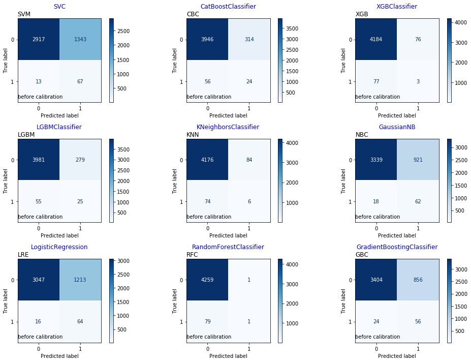

```python
confusion_matrix(classifiers_A,nameA,X_train, y_train,X_test,y_test,calibration=False)
```

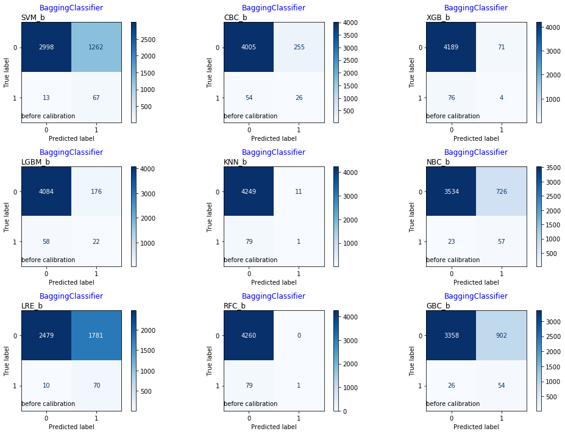

```python
confusion_matrix(classifiers_B,nameB,X_train, y_train,X_test,y_test,calibration=False)
```

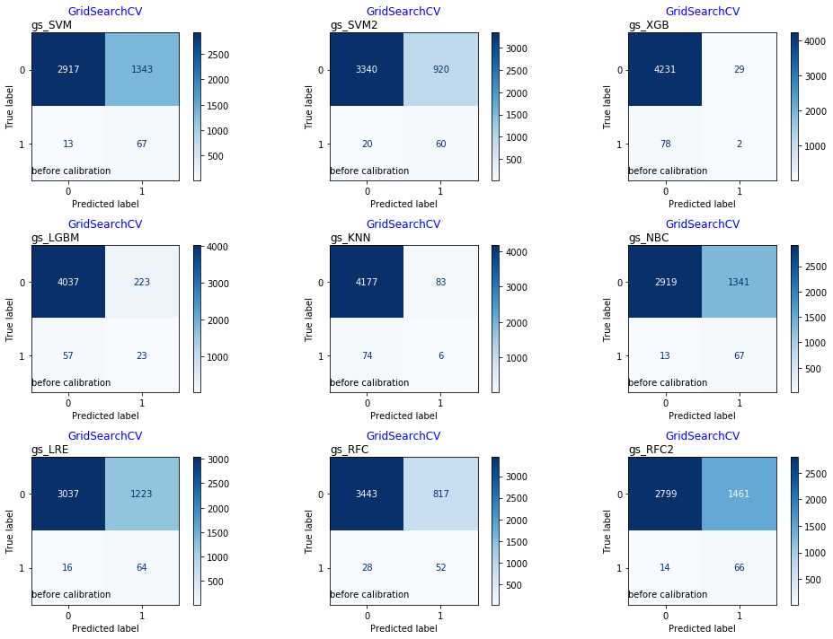

```python
confusion_matrix(classifiers_F,nameF,X_train, y_train,X_test,y_test,calibration=False)
```

## Recall - Precision!

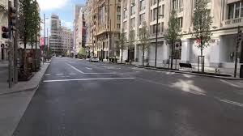

```python
def Recall_Precision(six_classifiers,name, X_train, y_train,X_test,y_test,calibration=True):

    from sklearn.datasets import make_classification
    from sklearn.calibration import CalibratedClassifierCV, calibration_curve

    import numpy as np
    import matplotlib.pyplot as plt
    from sklearn import metrics
    from sklearn.metrics import classification_report, confusion_matrix
    from sklearn.metrics import confusion_matrix, log_loss, auc, roc_curve, roc_auc_score, recall_score, precision_recall_curve
    from sklearn.metrics import make_scorer, precision_score, fbeta_score, f1_score, classification_report
    from sklearn.metrics import accuracy_score
    from mlxtend.plotting import plot_learning_curves
    from prettytable import PrettyTable
    import time

    start_time = time.time()

    #for cls in six_classifiers:
    #    cls.fit(X_train, y_train)


    Recall_Training = ['Recall Training: ']
    Precision_Training = ['Precision Training: ']
    Recall_Test= ['Recall Test: ']
    Precision_Test = ['Precision Test: ']

    CAL_Recall_Training = ['CAL_Recall Training: ']
    CAL_Precision_Training = ['CAL_Precision Training: ']
    CAL_Recall_Test= ['CAL_Recall Test: ']
    CAL_Precision_Test = ['CAL_Precision Test: ']

    def compute_metric2(model):

        Recall_Training = np.round(recall_score(y_train, model.predict(X_train)), decimals=3)
        Precision_Training = np.round(precision_score(y_train, model.predict(X_train)), decimals=3)
        Recall_Test = np.round(recall_score(y_test, model.predict(X_test)), decimals=3)
        Precision_Test = np.round(precision_score(y_test, model.predict(X_test)), decimals=3)

        return Recall_Training, Precision_Training, Recall_Test, Precision_Test

    for cls in six_classifiers:

        results = compute_metric2(cls)
        Recall_Training.append(results[0])
        Precision_Training.append(results[1])
        Recall_Test.append(blue(results[2],'bold'))
        Precision_Test.append((blue(results[3],'bold')))


    t = PrettyTable(['Name', name[0],name[1],name[2],name[3],name[4],name[5],name[6],name[7],name[8]])
    t.add_row(Recall_Training)
    t.add_row(Precision_Training)
    t.add_row(Recall_Test)
    t.add_row(Precision_Test)


    print(blue('Models before calibration','bold'))
    g = (time.time() - start_time)
    g = np.round(g)
    print('time: %s seconds' % g)
    print(t)

  ### ---------------------------------------------------------


    if calibration != True:
        print()
    else:
        print(blue('Models after calibration','bold'))


        def calibration(model):

            calibrated = CalibratedClassifierCV(model, method='sigmoid', cv=5)
            calibrated.fit(X_train, y_train)



            CAL_Recall_Training = np.round(recall_score(y_train, calibrated.predict(X_train)), decimals=3)
            CAL_Precision_Training = np.round(precision_score(y_train, calibrated.predict(X_train)), decimals=3)
            CAL_Recall_Test = np.round(recall_score(y_test, calibrated.predict(X_test)), decimals=3)
            CAL_Precision_Test = np.round(precision_score(y_test, calibrated.predict(X_test)), decimals=3)

            return CAL_Recall_Training, CAL_Precision_Training, CAL_Recall_Test, CAL_Precision_Test

        start_time = time.time()

        for cls in six_classifiers:

            results = calibration(cls)
            CAL_Recall_Training.append(results[0])
            CAL_Precision_Training.append(results[1])
            CAL_Recall_Test.append(blue(results[2],'bold'))
            CAL_Precision_Test.append((blue(results[3],'bold')))

        k = PrettyTable(['Name', name[0],name[1],name[2],name[3],name[4],name[5],name[6],name[7],name[8]])
        k.add_row(CAL_Recall_Training)
        k.add_row(CAL_Precision_Training)
        k.add_row(CAL_Recall_Test)
        k.add_row(CAL_Precision_Test)


        n = (time.time() - start_time)
        n = np.round(n)
        print('time: %s seconds' % n)
        print(k)
    print(blue('Wskaźniki pokazują RECALL i PRECISION dla klasy 1','bold'))
    print(blue('RECALL', 'bold'), blue('procentowy udział chorych dobrze zdiagnozowanych wśród wszystkich ludzi chorych','italic'))
    print(blue('PRECISION', 'bold'), blue('procentowy udział chorych dobrze zdiagnozowanych w populacji ludzi zdiagnozowanych fałszywie (zdrowych uznanych przez model za chorych) i dobrze zdiagnozowanych (chorych uznanych przez model za chorych)','italic'))
```

```python
Recall_Precision(classifiers_A,nameA,X_train, y_train,X_test,y_test,calibration=False)
```

```
Models before calibration
time: 77.0 seconds
+----------------------+-------+-------+-------+-------+-------+-------+-------+-------+-------+
|         Name         |  SVM  |  CBC  |  XGB  |  LGBM |  KNN  |  NBC  |  LRE  |  RFC  |  GBC  |
+----------------------+-------+-------+-------+-------+-------+-------+-------+-------+-------+
|  Recall Training:    | 0.869 |  1.0  |  1.0  |  1.0  |  1.0  | 0.766 | 0.794 |  1.0  | 0.919 |
| Precision Training:  | 0.734 | 0.944 | 0.993 | 0.948 |  1.0  | 0.776 | 0.737 |  1.0  | 0.815 |
|    Recall Test:      | 0.838 |  0.3  | 0.038 | 0.312 | 0.075 | 0.775 |  0.8  | 0.012 |  0.7  |
|   Precision Test:    | 0.048 | 0.071 | 0.038 | 0.082 | 0.067 | 0.063 |  0.05 |  0.5  | 0.061 |
+----------------------+-------+-------+-------+-------+-------+-------+-------+-------+-------+

Wskaźniki pokazują RECALL i PRECISION dla klasy 1
RECALL procentowy udział chorych dobrze zdiagnozowanych wśród wszystkich ludzi chorych
PRECISION procentowy udział chorych dobrze zdiagnozowanych w populacji ludzi zdiagnozowanych fałszywie (zdrowych uznanych przez model za chorych) i dobrze zdiagnozowanych (chorych uznanych przez model za chorych)
```

```python
Recall_Precision(classifiers_B,nameB,X_train, y_train,X_test,y_test,calibration=False)
```

```
Models before calibration
time: 471.0 seconds
+----------------------+-------+-------+-------+--------+-------+-------+-------+-------+-------+
|         Name         | SVM_b | CBC_b | XGB_b | LGBM_b | KNN_b | NBC_b | LRE_b | RFC_b | GBC_b |
+----------------------+-------+-------+-------+--------+-------+-------+-------+-------+-------+
|  Recall Training:    | 0.831 |  1.0  |  1.0  |  1.0   |  1.0  | 0.638 | 0.862 |  1.0  | 0.922 |
| Precision Training:  | 0.737 | 0.955 | 0.994 | 0.967  |  1.0  | 0.783 | 0.672 |  1.0  | 0.811 |
|    Recall Test:      | 0.838 | 0.325 |  0.05 | 0.275  | 0.012 | 0.712 | 0.875 | 0.012 | 0.675 |
|   Precision Test:    |  0.05 | 0.093 | 0.053 | 0.111  | 0.083 | 0.073 | 0.038 |  1.0  | 0.056 |
+----------------------+-------+-------+-------+--------+-------+-------+-------+-------+-------+

Wskaźniki pokazują RECALL i PRECISION dla klasy 1
RECALL procentowy udział chorych dobrze zdiagnozowanych wśród wszystkich ludzi chorych
PRECISION procentowy udział chorych dobrze zdiagnozowanych w populacji ludzi zdiagnozowanych fałszywie (zdrowych uznanych przez model za chorych) i dobrze zdiagnozowanych (chorych uznanych przez model za chorych)
```

```python
Recall_Precision(classifiers_F,nameF,X_train, y_train,X_test,y_test,calibration=False)
```

```
Models before calibration
time: 116.0 seconds
+----------------------+--------+---------+--------+---------+--------+--------+--------+--------+---------+
|         Name         | gs_SVM | gs_SVM2 | gs_XGB | gs_LGBM | gs_KNN | gs_NBC | gs_LRE | gs_RFC | gs_RFC2 |
+----------------------+--------+---------+--------+---------+--------+--------+--------+--------+---------+
|  Recall Training:    | 0.869  |  0.753  |  1.0   |   1.0   |  1.0   |  0.85  | 0.797  | 0.941  |  0.894  |
| Precision Training:  | 0.734  |  0.778  |  1.0   |  0.962  |  1.0   | 0.728  | 0.736  | 0.836  |  0.723  |
|    Recall Test:      | 0.838  |   0.75  | 0.025  |  0.288  | 0.075  | 0.838  |  0.8   |  0.65  |  0.825  |
|   Precision Test:    | 0.048  |  0.061  | 0.065  |  0.093  | 0.067  | 0.048  |  0.05  |  0.06  |  0.043  |
+----------------------+--------+---------+--------+---------+--------+--------+--------+--------+---------+

Wskaźniki pokazują RECALL i PRECISION dla klasy 1
RECALL procentowy udział chorych dobrze zdiagnozowanych wśród wszystkich ludzi chorych
PRECISION procentowy udział chorych dobrze zdiagnozowanych w populacji ludzi zdiagnozowanych fałszywie (zdrowych uznanych przez model za chorych) i dobrze zdiagnozowanych (chorych uznanych przez model za chorych)
```

## Classification score

```python
def classification_score(six_classifiers,name, X_train, y_train,X_test,y_test,calibration=True):

    from sklearn.datasets import make_classification
    from sklearn.calibration import CalibratedClassifierCV, calibration_curve
    from sklearn.metrics import precision_recall_fscore_support as score
    import time

    start_time = time.time()

    Precision_0 = ['Precision_0: ']
    Precision_1 = ['Precision_1: ']
    Recall_0 = ['Recall_0: ']
    Recall_1 = ['Recall_1: ']
    f1_score_0 = ['f1-score_0: ']
    f1_score_1 = ['f1-score_1: ']
    Support_0 = ['Support_0: ']
    Support_1 = ['Support_1: ']


    CAL_Precision_0 = ['CAL_Precision_0: ']
    CAL_Precision_1 = ['CAL_Precision_1: ']
    CAL_Recall_0 = ['CAL_Recall_0: ']
    CAL_Recall_1 = ['CAL_Recall_1: ']
    CAL_f1_score_0 = ['CAL_f1-score_0: ']
    CAL_f1_score_1 = ['CAL_f1-score_1: ']
    CAL_Support_0 = ['CAL_Support_0: ']
    CAL_Support_1 = ['CAL_Support_1: ']

    #for cls in six_classifiers:
    #    cls.fit(X_train, y_train)


    def compute_metric4(model):

        precision, recall, fscore, support = score(y_test, model.predict(X_test))

        Precision_0 = np.round(precision[:1],decimals=3).item()
        Precision_1 = np.round(precision[1:],decimals=3).item()
        Recall_0 = np.round(recall[:1],decimals=3).item()
        Recall_1 = np.round(recall[1:],decimals=3).item()
        f1_score_0 = np.round(fscore[:1],decimals=3).item()
        f1_score_1 = np.round(fscore[1:],decimals=3).item()
        Support_0 = np.round(support[:1],decimals=3).item()
        Support_1 = np.round(support[1:],decimals=3).item()

        return Precision_0, Precision_1, Recall_0, Recall_1, f1_score_0, f1_score_1, Support_0, Support_1

    for cls in six_classifiers:

        results = compute_metric4(cls)
        Precision_0.append(results[0])
        Precision_1.append(blue(results[1],'bold'))
        Recall_0.append(results[2])
        Recall_1.append(blue(results[3],'bold'))
        f1_score_0.append(results[4])
        f1_score_1.append(blue(results[5],'bold'))
        Support_0.append(results[6])
        Support_1.append(blue(results[7],'bold'))


    t = PrettyTable(['Name', name[0],name[1],name[2],name[3],name[4],name[5],name[6],name[7],name[8]])
    t.add_row(Precision_0)
    t.add_row(Precision_1)
    t.add_row(Recall_0)
    t.add_row(Recall_1)
    t.add_row(f1_score_0)
    t.add_row(f1_score_1)
    t.add_row(Support_0)
    t.add_row(Support_1)


    print(blue('Models before calibration','bold'))
    g = (time.time() - start_time)
    g = np.round(g)
    print('time: %s seconds' % g)
    print(t)

   ## ------------------------------------------

    if calibration != True:
        print()
    else:
        print(blue('Models after calibration','bold'))

        start_time = time.time()

        def calibration(model):

            calibrated = CalibratedClassifierCV(model, method='sigmoid', cv=5)
            calibrated.fit(X_train, y_train)
            precision, recall, fscore, support = score(y_test, calibrated.predict(X_test))

            CAL_Precision_0 = np.round(precision[:1],decimals=3).item()
            CAL_Precision_1 = np.round(precision[1:],decimals=3).item()
            CAL_Recall_0 = np.round(recall[:1],decimals=3).item()
            CAL_Recall_1 = np.round(recall[1:],decimals=3).item()
            CAL_f1_score_0 = np.round(fscore[:1],decimals=3).item()
            CAL_f1_score_1 = np.round(fscore[1:],decimals=3).item()
            CAL_Support_0 = np.round(support[:1],decimals=3).item()
            CAL_Support_1 = np.round(support[1:],decimals=3).item()

            return CAL_Precision_0, CAL_Precision_1, CAL_Recall_0, CAL_Recall_1, CAL_f1_score_0, CAL_f1_score_1, CAL_Support_0, CAL_Support_1

        for cls in six_classifiers:

            results = calibration(cls)
            CAL_Precision_0.append(results[0])
            CAL_Precision_1.append(blue(results[1],'bold'))
            CAL_Recall_0.append(results[2])
            CAL_Recall_1.append(blue(results[3],'bold'))
            CAL_f1_score_0.append(results[4])
            CAL_f1_score_1.append(blue(results[5],'bold'))
            CAL_Support_0.append(results[6])
            CAL_Support_1.append(blue(results[7],'bold'))

        k = PrettyTable(['Name', name[0],name[1],name[2],name[3],name[4],name[5],name[6],name[7],name[8]])
        k.add_row(CAL_Precision_0)
        k.add_row(CAL_Precision_1)
        k.add_row(CAL_Recall_0)
        k.add_row(CAL_Recall_1)
        k.add_row(CAL_f1_score_0)
        k.add_row(CAL_f1_score_1)
        k.add_row(CAL_Support_0)
        k.add_row(CAL_Support_1)

        n = (time.time() - start_time)
        n = np.round(n)
        print('time: %s seconds' % n)
        print(k)
    print(blue('RECALL', 'bold'), blue('procentowy udział chorych dobrze zdiagnozowanych wśród wszystkich ludzi chorych','italic'))
    print(blue('PRECISION', 'bold'), blue('procentowy udział chorych dobrze zdiagnozowanych w populacji ludzi zdiagnozowanych fałszywie (zdrowych uznanych przez model za chorych) i dobrze zdiagnozowanych (chorych uznanych przez model za chorych)','italic'))
```

```python
classification_score(classifiers_A,nameA,X_train, y_train,X_test,y_test,calibration=False)
```

```
Models before calibration
time: 4.0 seconds
+---------------+-------+-------+-------+-------+-------+-------+-------+-------+-------+
|      Name     |  SVM  |  CBC  |  XGB  |  LGBM |  KNN  |  NBC  |  LRE  |  RFC  |  GBC  |
+---------------+-------+-------+-------+-------+-------+-------+-------+-------+-------+
| Precision_0:  | 0.996 | 0.986 | 0.982 | 0.986 | 0.983 | 0.995 | 0.995 | 0.982 | 0.993 |
| Precision_1:  | 0.048 | 0.071 | 0.038 | 0.082 | 0.067 | 0.063 |  0.05 |  0.5  | 0.061 |
|   Recall_0:   | 0.685 | 0.926 | 0.982 | 0.935 |  0.98 | 0.784 | 0.715 |  1.0  | 0.799 |
|   Recall_1:   | 0.838 |  0.3  | 0.038 | 0.312 | 0.075 | 0.775 |  0.8  | 0.012 |  0.7  |
|  f1-score_0:  | 0.811 | 0.955 | 0.982 |  0.96 | 0.981 | 0.877 | 0.832 | 0.991 | 0.886 |
|  f1-score_1:  |  0.09 | 0.115 | 0.038 |  0.13 | 0.071 | 0.117 | 0.094 | 0.024 | 0.113 |
|  Support_0:   |  4260 |  4260 |  4260 |  4260 |  4260 |  4260 |  4260 |  4260 |  4260 |
|  Support_1:   |   80  |   80  |   80  |   80  |   80  |   80  |   80  |   80  |   80  |
+---------------+-------+-------+-------+-------+-------+-------+-------+-------+-------+

RECALL procentowy udział chorych dobrze zdiagnozowanych wśród wszystkich ludzi chorych
PRECISION procentowy udział chorych dobrze zdiagnozowanych w populacji ludzi zdiagnozowanych fałszywie (zdrowych uznanych przez model za chorych) i dobrze zdiagnozowanych (chorych uznanych przez model za chorych)
```

```python
classification_score(classifiers_B,nameB,X_train, y_train,X_test,y_test,calibration=False)
```

```
Models before calibration
time: 27.0 seconds
+---------------+-------+-------+-------+--------+-------+-------+-------+-------+-------+
|      Name     | SVM_b | CBC_b | XGB_b | LGBM_b | KNN_b | NBC_b | LRE_b | RFC_b | GBC_b |
+---------------+-------+-------+-------+--------+-------+-------+-------+-------+-------+
| Precision_0:  | 0.996 | 0.987 | 0.982 | 0.986  | 0.982 | 0.994 | 0.996 | 0.982 | 0.992 |
| Precision_1:  |  0.05 | 0.093 | 0.053 | 0.111  | 0.083 | 0.073 | 0.038 |  1.0  | 0.056 |
|   Recall_0:   | 0.704 |  0.94 | 0.983 | 0.959  | 0.997 |  0.83 | 0.582 |  1.0  | 0.788 |
|   Recall_1:   | 0.838 | 0.325 |  0.05 | 0.275  | 0.012 | 0.712 | 0.875 | 0.012 | 0.675 |
|  f1-score_0:  | 0.825 | 0.963 | 0.983 | 0.972  |  0.99 | 0.904 | 0.735 | 0.991 | 0.879 |
|  f1-score_1:  | 0.095 | 0.144 | 0.052 | 0.158  | 0.022 | 0.132 | 0.073 | 0.025 | 0.104 |
|  Support_0:   |  4260 |  4260 |  4260 |  4260  |  4260 |  4260 |  4260 |  4260 |  4260 |
|  Support_1:   |   80  |   80  |   80  |   80   |   80  |   80  |   80  |   80  |   80  |
+---------------+-------+-------+-------+--------+-------+-------+-------+-------+-------+

RECALL procentowy udział chorych dobrze zdiagnozowanych wśród wszystkich ludzi chorych
PRECISION procentowy udział chorych dobrze zdiagnozowanych w populacji ludzi zdiagnozowanych fałszywie (zdrowych uznanych przez model za chorych) i dobrze zdiagnozowanych (chorych uznanych przez model za chorych)
```

```python
classification_score(classifiers_F,nameF,X_train, y_train,X_test,y_test,calibration=False)
```

```
Models before calibration
time: 7.0 seconds
+---------------+--------+---------+--------+---------+--------+--------+--------+--------+---------+
|      Name     | gs_SVM | gs_SVM2 | gs_XGB | gs_LGBM | gs_KNN | gs_NBC | gs_LRE | gs_RFC | gs_RFC2 |
+---------------+--------+---------+--------+---------+--------+--------+--------+--------+---------+
| Precision_0:  | 0.996  |  0.994  | 0.982  |  0.986  | 0.983  | 0.996  | 0.995  | 0.992  |  0.995  |
| Precision_1:  | 0.048  |  0.061  | 0.065  |  0.093  | 0.067  | 0.048  |  0.05  |  0.06  |  0.043  |
|   Recall_0:   | 0.685  |  0.784  | 0.993  |  0.948  | 0.981  | 0.685  | 0.713  | 0.808  |  0.657  |
|   Recall_1:   | 0.838  |   0.75  | 0.025  |  0.288  | 0.075  | 0.838  |  0.8   |  0.65  |  0.825  |
|  f1-score_0:  | 0.811  |  0.877  | 0.988  |  0.966  | 0.982  | 0.812  | 0.831  | 0.891  |  0.791  |
|  f1-score_1:  |  0.09  |  0.113  | 0.036  |  0.141  | 0.071  |  0.09  | 0.094  |  0.11  |  0.082  |
|  Support_0:   |  4260  |   4260  |  4260  |   4260  |  4260  |  4260  |  4260  |  4260  |   4260  |
|  Support_1:   |   80   |    80   |   80   |    80   |   80   |   80   |   80   |   80   |    80   |
+---------------+--------+---------+--------+---------+--------+--------+--------+--------+---------+

RECALL procentowy udział chorych dobrze zdiagnozowanych wśród wszystkich ludzi chorych
PRECISION procentowy udział chorych dobrze zdiagnozowanych w populacji ludzi zdiagnozowanych fałszywie (zdrowych uznanych przez model za chorych) i dobrze zdiagnozowanych (chorych uznanych przez model za chorych)
```

## AUC score

```python
def AUC_score(six_classifiers,name, X_train, y_train,X_test,y_test,calibration=True):

    from sklearn.calibration import CalibratedClassifierCV, calibration_curve
    from sklearn import metrics
    import time

    start_time = time.time()

    #for cls in six_classifiers:
    #    cls.fit(X_train, y_train)

    AUC_train = ['AUC_train: ']
    AUC_test = ['AUC_test: ']
    CAL_AUC_train = ['AUC_train: ']
    CAL_AUC_test = ['AUC_test: ']


    def compute_metric(model):

        auc_train = np.round(metrics.roc_auc_score(y_train,model.predict_proba(X_train)[:,1]),decimals=3)
        auc_test = np.round(metrics.roc_auc_score(y_test,model.predict_proba(X_test)[:,1]),decimals=3)

        return auc_train, auc_test

    for cls in six_classifiers:

        results = compute_metric(cls)
        AUC_train.append(results[0])
        AUC_test.append(blue(results[1],'bold'))


    t = PrettyTable(['Name', name[0],name[1],name[2],name[3],name[4],name[5],name[6],name[7],name[8]])
    t.add_row(AUC_train)
    t.add_row(AUC_test)


    print(blue('Models before calibration','bold'))
    g = (time.time() - start_time)
    g = np.round(g)
    print('time: %s secondS' % g)
    print(t)

    if calibration != True:
        print()
    else:
        print(blue('Models after calibration','bold'))

        start_time = time.time()

        def calibration(model):

            calibrated = CalibratedClassifierCV(model, method='sigmoid', cv=5)
            calibrated.fit(X_train, y_train)

            CAL_AUC_train = np.round(metrics.roc_auc_score(y_train,calibrated.predict_proba(X_train)[:,1]),decimals=3)
            CAL_AUC_test = np.round(metrics.roc_auc_score(y_test,calibrated.predict_proba(X_test)[:,1]),decimals=3)

            return CAL_AUC_train, CAL_AUC_test


        for cls in six_classifiers:

            results = calibration(cls)
            CAL_AUC_train.append(results[0])
            CAL_AUC_test.append(blue(results[1],'bold'))


        k = PrettyTable(['Name', name[0],name[1],name[2],name[3],name[4],name[5],name[6],name[7],name[8]])
        k.add_row(CAL_AUC_train)
        k.add_row(CAL_AUC_test)

        n = (time.time() - start_time)
        n = np.round(n)
        print('time: %s seconds' % n)
        print(k)
```

```python
AUC_score(classifiers_A,nameA,X_train, y_train,X_test,y_test,calibration=False)
```

```
Models before calibration
time: 37.0 secondS
+-------------+-------+-------+-------+-------+-------+-------+-------+-------+-------+
|     Name    |  SVM  |  CBC  |  XGB  |  LGBM |  KNN  |  NBC  |  LRE  |  RFC  |  GBC  |
+-------------+-------+-------+-------+-------+-------+-------+-------+-------+-------+
| AUC_train:  |  0.85 | 0.996 |  1.0  | 0.999 |  1.0  |  0.84 | 0.827 |  1.0  |  0.93 |
|  AUC_test:  | 0.848 | 0.784 | 0.755 | 0.794 | 0.528 | 0.847 | 0.844 | 0.802 | 0.823 |
+-------------+-------+-------+-------+-------+-------+-------+-------+-------+-------+
```

```python
AUC_score(classifiers_B,nameB,X_train, y_train,X_test,y_test,calibration=False)
```

```
Models before calibration
time: 236.0 secondS
+-------------+-------+-------+-------+--------+-------+-------+-------+-------+-------+
|     Name    | SVM_b | CBC_b | XGB_b | LGBM_b | KNN_b | NBC_b | LRE_b | RFC_b | GBC_b |
+-------------+-------+-------+-------+--------+-------+-------+-------+-------+-------+
| AUC_train:  | 0.844 | 0.999 |  1.0  |  1.0   |  1.0  | 0.836 | 0.793 |  1.0  | 0.937 |
|  AUC_test:  |  0.85 | 0.827 | 0.787 | 0.819  | 0.611 | 0.844 | 0.782 | 0.827 | 0.817 |
+-------------+-------+-------+-------+--------+-------+-------+-------+-------+-------+
```

```python
AUC_score(classifiers_F,nameF,X_train, y_train,X_test,y_test,calibration=False)
```

```
Models before calibration
time: 56.0 secondS
+-------------+--------+---------+--------+---------+--------+--------+--------+--------+---------+
|     Name    | gs_SVM | gs_SVM2 | gs_XGB | gs_LGBM | gs_KNN | gs_NBC | gs_LRE | gs_RFC | gs_RFC2 |
+-------------+--------+---------+--------+---------+--------+--------+--------+--------+---------+
| AUC_train:  |  0.85  |  0.849  |  1.0   |   1.0   |  1.0   | 0.845  | 0.827  | 0.958  |  0.859  |
|  AUC_test:  | 0.848  |  0.847  | 0.772  |  0.779  | 0.528  | 0.843  | 0.843  | 0.806  |  0.831  |
+-------------+--------+---------+--------+---------+--------+--------+--------+--------+---------+
```